# [Phystech@DataScience](https://mipt-stats.gitlab.io/courses/ad_mipt.html)

## Задание 2

**Правила:**

- Выполненную работу нужно отправить телеграм-боту.
- Дедлайн **23 февраля в 15:00 (отбор)**. После дедлайна работы не принимаются кроме случаев наличия уважительной причины с подтверждающими документами.
- Прислать нужно ноутбук в формате `ipynb`
- Решения, размещенные на каких-либо интернет-ресурсах, не принимаются. Публикация решения может быть приравнена к предоставлении возможности списать.
- Для выполнения задания используйте этот ноутбук в качествие основы, ничего не удаляя из него.

```python
import numpy as np
import pandas as pd
from sklearn.datasets import load_diabetes
from sklearn.model_selection import train_test_split
from sklearn.linear_model import LinearRegression
import scipy as sp

import matplotlib.pyplot as plt
import seaborn as sns
sns.set(font_scale=1.3)
```

Рассмотрим данные исследования 2004 года о зависимости риска развития диабета от пола, возраста, индекса массы тела, среднего кровяного давления и других показателей.

Функция `sklearn.datasets.load_diabetes()` возвращает словарь. В поле `data` записана матрица регрессоров, в которой данные предварительно центрированы и нормированы. В поле `target` записана мера прогрессирования заболевания в течении года. В поле `DESCR` можно прочитать подробнее о данных.

### Загрузка данных

```python
data = load_diabetes()
```

Посмотрим на описание датасета.

```python
print(data['DESCR'])
```

```
.. _diabetes_dataset:

Diabetes dataset
----------------

Ten baseline variables, age, sex, body mass index, average blood
pressure, and six blood serum measurements were obtained for each of n =
442 diabetes patients, as well as the response of interest, a
quantitative measure of disease progression one year after baseline.

**Data Set Characteristics:**

  :Number of Instances: 442

  :Number of Attributes: First 10 columns are numeric predictive values

  :Target: Column 11 is a quantitative measure of disease progression one year after baseline

  :Attribute Information:
      - age     age in years
      - sex
      - bmi     body mass index
      - bp      average blood pressure
      - s1      tc, total serum cholesterol
      - s2      ldl, low-density lipoproteins
      - s3      hdl, high-density lipoproteins
      - s4      tch, total cholesterol / HDL
      - s5      ltg, possibly log of serum triglycerides level
      - s6      glu, blood sugar level

Note: Each of these 10 feature variables have been mean centered and scaled by the standard deviation times `n_samples` (i.e. the sum of squares of each column totals 1).

Source URL:
https://www4.stat.ncsu.edu/~boos/var.select/diabetes.html

For more information see:
Bradley Efron, Trevor Hastie, Iain Johnstone and Robert Tibshirani (2004) "Least Angle Regression," Annals of Statistics (with discussion), 407-499.
(https://web.stanford.edu/~hastie/Papers/LARS/LeastAngle_2002.pdf)
```

Поле `data` содержит матрицу размера 442 $\times$ 10, где 442 — количество пациентов, а 10 — количество признаков (возраст, пол, и т.д.). Строки матрицы соответствуют пациентам, столбцы — признакам.

```python
data['data'].shape
```

```
(442, 10)
```

Целевая переменная $-$ мера прогрессирования заболевания в течении года.

```python
data['target'].shape
```

```
(442,)
```

Создайте матрицу регрессоров $X$ и столбец наблюдений $y$.

```python
X, y = data['data'], data['target']
```

### Обучение моделей

Разбейте данные случайно на две части — обучающую и тестовую в соотношении 80:20.

Если что-то забыли или что-то не понятно, можно почитать справку:

```python
train_test_split?
```

[output not shown]

[output cut: 40 more lines]

[output not shown]

```python
X_train, X_test, y_train, y_test = train_test_split(X, y, test_size=0.2, random_state=42)

print(X_train.shape, X_test.shape, y_train.shape, y_test.shape)
```

```
(353, 10) (89, 10) (353,) (89,)
```

Заведите модель линейной регрессии из `sklearn` и обучите ее по обучающей части данных.

```python
model = LinearRegression().fit(X_train, y_train)
```

Выведите кооэффициенты модели, включая свободный член.

```python
display(pd.DataFrame({'intercept': [model.intercept_],
                        '1': [model.coef_[0]],
                        '2': [model.coef_[1]],
                        '3': [model.coef_[2]],
                        '4': [model.coef_[3]],
                        '5': [model.coef_[4]],
                        '6': [model.coef_[5]],
                        '7': [model.coef_[6]],
                        '8': [model.coef_[7]],
                        '9': [model.coef_[8]],
                        '10': [model.coef_[9]]}))
```

|  | intercept | 1 | 2 | 3 | 4 | 5 | 6 | 7 | 8 | 9 | 10 |
| --- | --- | --- | --- | --- | --- | --- | --- | --- | --- | --- | --- |
| 0 | 151.345655 | 37.900314 | -241.966248 | 542.425753 | 347.708305 | -931.461261 | 518.044055 | 163.403535 | 275.310038 | 736.189098 | 48.671125 |

Посчитайте предсказания построенной модели на тестовой выборке

```python
y_pred = LinearRegression.predict(model, X_test)
```

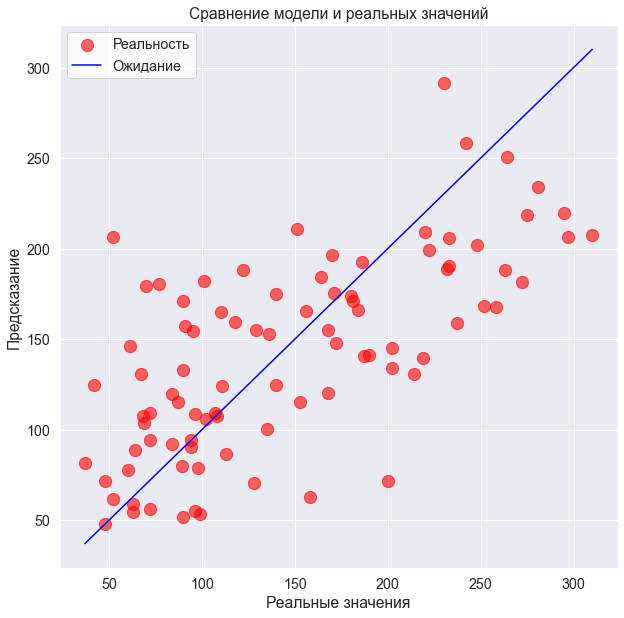

```python
plt.figure(figsize=(10, 10))
plt.title('Сравнение модели и реальных значений')
plt.ylabel('Предсказание')
plt.xlabel('Реальные значения')
plt.scatter(y_test, y_pred, 150, marker='o', c='red', alpha=0.6, label='Реальность')
x = np.linspace(y_test.min(), y_test.max(), 2)
plt.plot(x, x, 'blue', label='Ожидание')
plt.legend(facecolor='white')
```

Реализуйте метрики MSE, MAE, MAPE без использования `sklearn` и других готовых реализаций.

```python
def mean_squared_error(y_true, y_pred):
    return ((np.array(y_true) - np.array(y_pred)) ** 2).sum().mean()

def mean_absolute_error(y_true, y_pred):
    return (np.abs(np.array(y_true) - np.array(y_pred))).sum().mean()

def mean_absolute_percentage_error(y_true, y_pred):
    return (np.abs((np.array(y_true) - np.array(y_pred)) / np.array(y_true))).sum().mean()
```

Посчитайте MSE, MAE, MAPE на тестовой выборке и выведите с точностью до трех знаков после запятой.

```python
metrics = pd.DataFrame({"MSE": [np.round(mean_squared_error(y_test, y_pred), decimals=3)],
            "MAE": [np.round(mean_absolute_error(y_test, y_pred), decimals=3)],
            "MAPE": [np.round(mean_absolute_percentage_error(y_test, y_pred), decimals=3)]}, index=None)
display(metrics)
```

|  | MSE | MAE | MAPE |
| --- | --- | --- | --- |
| 0 | 258115.423 | 3808.656 | 33.375 |

### Своя реализация модели

Теперь реализуем линейную регрессию самостоятельно, используя формулы с лекции. Вам нужно только заполнить прочерки в методах `fit` и `predict`.

```python
class MyLinearRegression:
    """
    Класс, реализующий линейную регрессию c помощью МНК.
    """

    def __init__(self, fit_intercept=True):
        self.__intercept__ = fit_intercept

    def fit(self, X, Y, a=0.95):
        """
        Функция обучения модели.

        Предполагается модель Y = X * theta + epsilon.
        где X --- регрессор (матрица размера n x d),
        Y --- отклик (матрица размера n x 1),
        epsilon-ы имеют нормальное распределение

        Обратите внимание, здесь нет intercept_
        """
        self.n, self.d = X.shape

        x = np.array(X)
        y = np.array(Y)

        if self.__intercept__:
            x = np.hstack((np.full((self.n, 1), 1), x))
            self.intercept_, self.coef_= np.hsplit(np.dot(np.dot(np.linalg.inv(np.dot(x.transpose(), x)), x.transpose()), y), [1,])
            y_pred = np.dot(x, np.hstack((self.intercept_, self.coef_)))
        else:
            self.coef_ = np.dot(np.dot(np.linalg.inv(np.dot(x.transpose(), x)), x.transpose()), y)
            y_pred = np.dot(x, self.coef_)

        sigma2 = np.dot((y_pred - y).transpose(), (y_pred - y)) / (x.shape[0] - x.shape[1])
        cov = sigma2 * np.linalg.inv(np.dot(x.transpose(), x))
        self.conf_int_par = cov.diagonal() ** 0.5 * sp.stats.t.ppf((1 + a) / 2, x.shape[0] - x.shape[1])
        self.y_conf_int = np.zeros((500, x.shape[1] - self.__intercept__))
        self.y_pred_int = np.zeros((500, x.shape[1] - self.__intercept__))
        for i in range(x.shape[1] - self.__intercept__):
            x_lin = np.zeros((500, x.shape[1]))
            if self.__intercept__: x_lin[:,0] = np.ones(500)
            x_lin[:,i + self.__intercept__] = np.linspace(x[:,i + self.__intercept__].min(), x[:,i + self.__intercept__].max(), 500)
            self.y_conf_int[:,i] = sigma2 ** 0.5 * sp.stats.t.ppf((1 + a) / 2, x.shape[0] - x.shape[1]) * ((x_lin.dot(np.linalg.inv(np.dot(x.transpose(), x)))).dot(x_lin.transpose())).diagonal() ** 0.5
            self.y_pred_int[:,i] = sigma2 ** 0.5 * sp.stats.t.ppf((1 + a) / 2, x.shape[0] - x.shape[1]) * (np.ones(x_lin.shape[0]) + (x_lin.dot(np.linalg.inv(np.dot(x.transpose(), x)))).dot(x_lin.transpose()).diagonal()) ** 0.5


        return self


    def predict(self, X):
        """
        Возвращает предсказание отклика на новых объектах X
        и опционально доверительный/предсказательный интервал.

        X --- матрица объектов размера n x d

        """
        x = np.array(X)

        if self.__intercept__:
            x = np.hstack((np.full((x.shape[0], 1), 1), x))
            y_pred = np.dot(x, np.hstack((self.intercept_, self.coef_)))
        else:
            y_pred = np.dot(x, self.coef_)

        return y_pred
```

Обучите вашу модель на данных о диабете с добавлением свободного члена. Распечатайте коэффициенты и сравните их с коэффициентами модели из `sklearn`.

```python
my = MyLinearRegression(fit_intercept=True).fit(X_train, y_train, a=0.95)
y_my_pred = my.predict(X_test)
display(pd.DataFrame({'intercept': [my.intercept_[0], my.conf_int_par[0]],
                        '1': [my.coef_[0], my.conf_int_par[1]],
                        '2': [my.coef_[1], my.conf_int_par[2]],
                        '3': [my.coef_[2], my.conf_int_par[3]],
                        '4': [my.coef_[3], my.conf_int_par[4]],
                        '5': [my.coef_[4], my.conf_int_par[5]],
                        '6': [my.coef_[5], my.conf_int_par[6]],
                        '7': [my.coef_[6], my.conf_int_par[7]],
                        '8': [my.coef_[7], my.conf_int_par[8]],
                        '9': [my.coef_[8], my.conf_int_par[9]],
                        '10': [my.coef_[9], my.conf_int_par[10]]}, index=['coefficient', 'conf. interval']))
```

|  | intercept | 1 | 2 | 3 | 4 | 5 | 6 | 7 | 8 | 9 | 10 |
| --- | --- | --- | --- | --- | --- | --- | --- | --- | --- | --- | --- |
| coefficient | 151.345655 | 37.900314 | -241.966248 | 542.425753 | 347.708305 | -931.461261 | 518.044055 | 163.403535 | 275.310038 | 736.189098 | 48.671125 |
| conf. interval | 5.707695 | 135.827337 | 134.871187 | 151.366569 | 140.353306 | 887.362126 | 716.193650 | 458.322441 | 364.666714 | 378.514533 | 144.441860 |

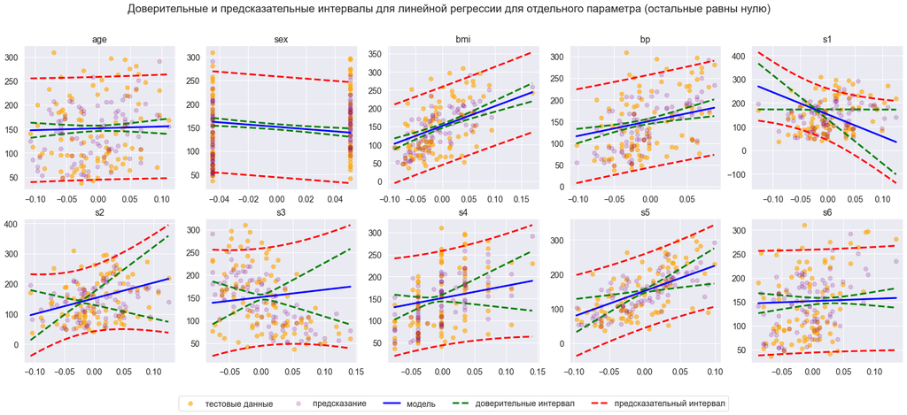

```python
fig = plt.figure(figsize=(27, 10))
axes = fig.subplots(nrows=2, ncols=5)
plt.suptitle('Доверительные и предсказательные интервалы для линейной регрессии для отдельного параметра (остальные равны нулю)')
columns = {0: 'age', 1: 'sex', 2: 'bmi', 3: 'bp', 4: 's1', 5: 's2', 6: 's3', 7: 's4', 8: 's5', 9: 's6'}
for i, ax in enumerate((fig.axes)):
    x = np.linspace(X_test[:,i].min(), X_test[:,i].max(), 500)
    ax.set_title(columns[i])
    ax.scatter(X_test[:,i], y_test, 50, marker='o', c='orange', alpha=0.6, label='тестовые данные')
    ax.scatter(X_test[:,i], y_my_pred, 50, marker='o', c='purple', alpha=0.2, label='предсказание')
    ax.plot(x, my.intercept_ + my.coef_[i] * x, 'blue', lw=3, label='модель')
    ax.errorbar(x, my.y_conf_int[:,i] + x * my.coef_[i] + my.intercept_, fmt='--', color='green', lw=3, label='доверительные интервал')
    ax.errorbar(x, -my.y_conf_int[:,i] + x * my.coef_[i] + my.intercept_, fmt='--', color='green', lw=3)
    ax.errorbar(x, my.y_pred_int[:,i] +x * my.coef_[i] + my.intercept_, fmt='--', color='red', lw=3, label='предсказательный интервал')
    ax.errorbar(x, -my.y_pred_int[:,i] +x * my.coef_[i] + my.intercept_, fmt='--', color='red', lw=3)
lines, labels = fig.axes[-1].get_legend_handles_labels()
fig.legend(lines, labels, ncol=5, loc='lower center', facecolor='white')
```

Коэффициенты совплаи

Теперь обучите модель без свободного члена.

```python
my_wo_in = MyLinearRegression(fit_intercept=False).fit(X_train, y_train, a=0.95)
y_my_wo_in_pred = my_wo_in.predict(X_test)
display(pd.DataFrame({'1': [my_wo_in.coef_[0], my_wo_in.conf_int_par[0]],
                        '2': [my_wo_in.coef_[1], my_wo_in.conf_int_par[1]],
                        '3': [my_wo_in.coef_[2], my_wo_in.conf_int_par[2]],
                        '4': [my_wo_in.coef_[3], my_wo_in.conf_int_par[3]],
                        '5': [my_wo_in.coef_[4], my_wo_in.conf_int_par[4]],
                        '6': [my_wo_in.coef_[5], my_wo_in.conf_int_par[5]],
                        '7': [my_wo_in.coef_[6], my_wo_in.conf_int_par[6]],
                        '8': [my_wo_in.coef_[7], my_wo_in.conf_int_par[7]],
                        '9': [my_wo_in.coef_[8], my_wo_in.conf_int_par[8]],
                        '10': [my_wo_in.coef_[9], my_wo_in.conf_int_par[9]]}, index=['coefficient', 'conf. interval']))
```

|  | 1 | 2 | 3 | 4 | 5 | 6 | 7 | 8 | 9 | 10 |
| --- | --- | --- | --- | --- | --- | --- | --- | --- | --- | --- |
| coefficient | 125.208090 | -258.203555 | 627.487528 | 346.318577 | -803.224037 | 312.818069 | 45.067586 | 211.977884 | 700.824788 | 144.689679 |
| conf. interval | 405.715562 | 402.973814 | 452.162496 | 419.357815 | 2651.285896 | 2139.770662 | 1369.344294 | 1089.554432 | 1130.946305 | 431.438279 |

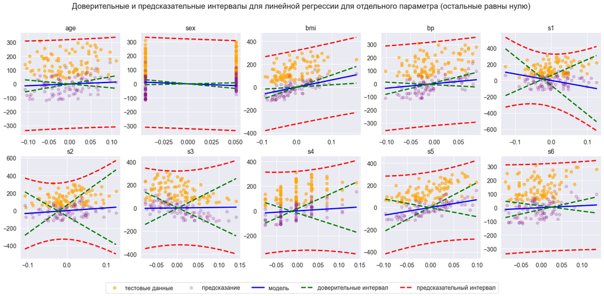

```python
fig = plt.figure(figsize=(25, 10))
axes = fig.subplots(nrows=2, ncols=5)
plt.suptitle('Доверительные и предсказательные интервалы для линейной регрессии для отдельного параметра (остальные равны нулю)')
columns = {0: 'age', 1: 'sex', 2: 'bmi', 3: 'bp', 4: 's1', 5: 's2', 6: 's3', 7: 's4', 8: 's5', 9: 's6'}
for i, ax in enumerate((fig.axes)):
    x = np.linspace(X_test[:,i].min(), X_test[:,i].max(), 500)
    ax.set_title(columns[i])
    ax.scatter(X_test[:,i], y_test, 50, marker='o', c='orange', alpha=0.6, label='тестовые данные')
    ax.scatter(X_test[:,i], y_my_wo_in_pred, 50, marker='o', c='purple', alpha=0.2, label='предсказание')
    ax.plot(x, my_wo_in.coef_[i] * x, 'blue', lw=3, label='модель')
    ax.errorbar(x, my_wo_in.y_conf_int[:,i] + x * my_wo_in.coef_[i], fmt='--', color='green', lw=3, label='доверительные интервал')
    ax.errorbar(x, -my_wo_in.y_conf_int[:,i] + x * my_wo_in.coef_[i], fmt='--', color='green', lw=3)
    ax.errorbar(x, my_wo_in.y_pred_int[:,i] +x * my_wo_in.coef_[i], fmt='--', color='red', lw=3, label='предсказательный интервал')
    ax.errorbar(x, -my_wo_in.y_pred_int[:,i] +x * my_wo_in.coef_[i], fmt='--', color='red', lw=3)
lines, labels = fig.axes[-1].get_legend_handles_labels()
fig.legend(lines, labels, ncol=5, loc='lower center', facecolor='white')
```

Сравните качество моделей со свободным членом и без него на тестовой выборке.

```python
metrics = pd.DataFrame({"MSE": [np.round(mean_squared_error(y_test, y_my_pred), decimals=3),
                                np.round(mean_squared_error(y_test, y_my_wo_in_pred), decimals=3)],
            "MAE": [np.round(mean_absolute_error(y_test, y_my_pred), decimals=3),
                    np.round(mean_absolute_error(y_test, y_my_wo_in_pred), decimals=3)],
            "MAPE": [np.round(mean_absolute_percentage_error(y_test, y_my_pred), decimals=3),
                    np.round(mean_absolute_percentage_error(y_test, y_my_wo_in_pred), decimals=3)]}, index=['intercept', 'no intercept'])
display(metrics)
```

|  | MSE | MAE | MAPE |
| --- | --- | --- | --- |
| intercept | 258115.423 | 3808.656 | 33.375 |
| no intercept | 2488590.024 | 14042.200 | 114.057 |

Сделайте выводы.

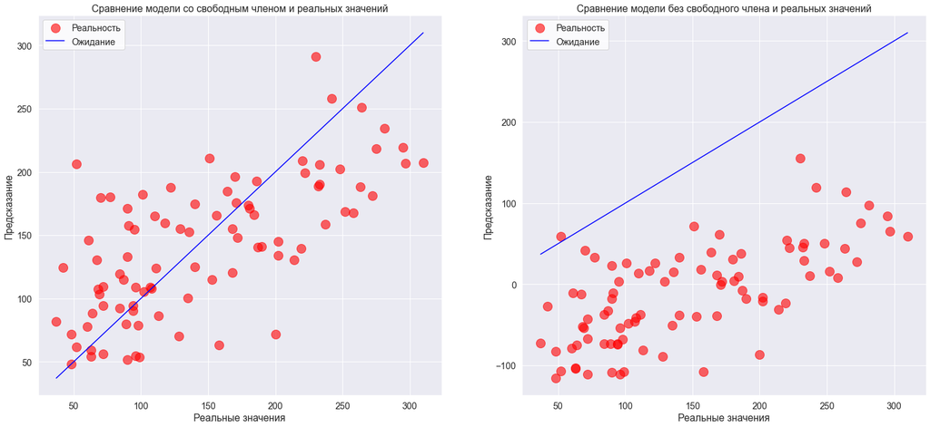

```python
plt.figure(figsize=(25, 11))
plt.subplot(1, 2, 1)
plt.title('Сравнение модели со свободным членом и реальных значений')
plt.ylabel('Предсказание')
plt.xlabel('Реальные значения')
plt.scatter(y_test, y_my_pred, 200, marker='o', c='red', alpha=0.6, label='Реальность')
x = np.linspace(y_test.min(), y_test.max(), 2)
plt.plot(x, x, 'blue', label='Ожидание')
plt.legend(facecolor='white')
plt.subplot(1, 2, 2)
plt.title('Сравнение модели без свободного члена и реальных значений')
plt.ylabel('Предсказание')
plt.xlabel('Реальные значения')
plt.scatter(y_test, y_my_wo_in_pred, 200, marker='o', c='red', alpha=0.6, label='Реальность')
x = np.linspace(y_test.min(), y_test.max(), 2)
plt.plot(x, x, 'blue', label='Ожидание')
plt.legend(facecolor='white')
```

Как видно из графиков, модель без свободного члена согласуется с тестовыми данными гораздо хуже. О том же говорят метрики MSE, MAE, MAPE, которые для модели без свободно члена дают значения в 3 и более раз большее. Доверительные интервалы коэффициентов также больше у модели без свободного члена. Вероятно, это связанно с тем, что свободным член "поглащает" ошибки измерений ($\varepsilon$), тем сам делая модель лучше.